# mpl_toolkits.axes_grid1.mpl_axes.Axes

**class*mpl_toolkits.axes_grid1.mpl_axes.Axes(*fig*, *args, *facecolor=None*, *frameon=True*, *sharex=None*, *sharey=None*, *label=''*, *xscale=None*, *yscale=None*, *box_aspect=None*, **kwargs)[[source]](https://github.com/matplotlib/matplotlib/blob/v3.7.1/lib/mpl_toolkits/axes_grid1/mpl_axes.py#L19-L56)**

Bases: `Axes`

Build an Axes in a figure.

**Parameters:**

**fig**`Figure`**

The Axes is built in the `Figure` *fig*.

**args**

`*args` can be a single `(left, bottom, width, height)` rectangle or a single `Bbox`. This specifies the rectangle (in figure coordinates) where the Axes is positioned.

`*args` can also consist of three numbers or a single three-digit number; in the latter case, the digits are considered as independent numbers. The numbers are interpreted as

```
(nrows,
ncols, index)
```

: `(nrows, ncols)` specifies the size of an array of subplots, and `index` is the 1-based index of the subplot being created. Finally, `*args` can also directly be a `SubplotSpec` instance.

**sharex, sharey**`Axes`, optional**

The x- or y-`axis` is shared with the x- or y-axis in the input `Axes`.

**frameon**bool, default: True**

Whether the Axes frame is visible.

**box_aspect**float, optional**

Set a fixed aspect for the Axes box, i.e. the ratio of height to width. See `set_box_aspect` for details.

**kwargs**

Other optional keyword arguments:

| Property | Description |
| --- | --- |
| `adjustable` | {'box', 'datalim'} |
| `agg_filter` | a filter function, which takes a (m, n, 3) float array and a dpi value, and returns a (m, n, 3) array and two offsets from the bottom left corner of the image |
| `alpha` | scalar or None |
| `anchor` | (float, float) or {'C', 'SW', 'S', 'SE', 'E', 'NE', ...} |
| `animated` | bool |
| `aspect` | {'auto', 'equal'} or float |
| `autoscale_on` | bool |
| `autoscalex_on` | unknown |
| `autoscaley_on` | unknown |
| `axes_locator` | Callable[[Axes, Renderer], Bbox] |
| `axisbelow` | bool or 'line' |
| `box_aspect` | float or None |
| `clip_box` | `Bbox` |
| `clip_on` | bool |
| `clip_path` | Patch or (Path, Transform) or None |
| `facecolor` or fc | color |
| `figure` | `Figure` |
| `frame_on` | bool |
| `gid` | str |
| `in_layout` | bool |
| `label` | object |
| `mouseover` | bool |
| `navigate` | bool |
| `navigate_mode` | unknown |
| `path_effects` | `AbstractPathEffect` |
| `picker` | None or bool or float or callable |
| `position` | [left, bottom, width, height] or `Bbox` |
| `prop_cycle` | unknown |
| `rasterization_zorder` | float or None |
| `rasterized` | bool |
| `sketch_params` | (scale: float, length: float, randomness: float) |
| `snap` | bool or None |
| `subplotspec` | unknown |
| `title` | str |
| `transform` | `Transform` |
| `url` | str |
| `visible` | bool |
| `xbound` | unknown |
| `xlabel` | str |
| `xlim` | (bottom: float, top: float) |
| `xmargin` | float greater than -0.5 |
| `xscale` | unknown |
| `xticklabels` | unknown |
| `xticks` | unknown |
| `ybound` | unknown |
| `ylabel` | str |
| `ylim` | (bottom: float, top: float) |
| `ymargin` | float greater than -0.5 |
| `yscale` | unknown |
| `yticklabels` | unknown |
| `yticks` | unknown |
| `zorder` | float |

**Returns:**

**`Axes`**

The new `Axes` object.

**class*AxisDict(*axes*)[[source]](https://github.com/matplotlib/matplotlib/blob/v3.7.1/lib/mpl_toolkits/axes_grid1/mpl_axes.py#L21-L41)**

Bases: [`dict`](https://docs.python.org/3/library/stdtypes.html#dict)

**__call__(*v, **kwargs)[[source]](https://github.com/matplotlib/matplotlib/blob/v3.7.1/lib/mpl_toolkits/axes_grid1/mpl_axes.py#L40-L41)**

Call self as a function.

**property*axis**

Convenience method to get or set some axis properties.

Call signatures:

```
xmin, xmax, ymin, ymax = axis()
xmin, xmax, ymin, ymax = axis([xmin, xmax, ymin, ymax])
xmin, xmax, ymin, ymax = axis(option)
xmin, xmax, ymin, ymax = axis(**kwargs)
```

**Parameters:**

**xmin, xmax, ymin, ymax**float, optional**

The axis limits to be set. This can also be achieved using

```
ax.set(xlim=(xmin, xmax), ylim=(ymin, ymax))
```

**option**bool or str**

If a bool, turns axis lines and labels on or off. If a string, possible values are:

[output not shown]

**emit**bool, default: True**

Whether observers are notified of the axis limit change. This option is passed on to `set_xlim` and `set_ylim`.

**Returns:**

**xmin, xmax, ymin, ymax**float**

The axis limits.

See also

**`matplotlib.axes.Axes.set_xlim`**

**`matplotlib.axes.Axes.set_ylim`**

**clear()[[source]](https://github.com/matplotlib/matplotlib/blob/v3.7.1/lib/mpl_toolkits/axes_grid1/mpl_axes.py#L47-L56)**

Clear the Axes.

**set(*, *adjustable=<UNSET>*, *agg_filter=<UNSET>*, *alpha=<UNSET>*, *anchor=<UNSET>*, *animated=<UNSET>*, *aspect=<UNSET>*, *autoscale_on=<UNSET>*, *autoscalex_on=<UNSET>*, *autoscaley_on=<UNSET>*, *axes_locator=<UNSET>*, *axisbelow=<UNSET>*, *box_aspect=<UNSET>*, *clip_box=<UNSET>*, *clip_on=<UNSET>*, *clip_path=<UNSET>*, *facecolor=<UNSET>*, *frame_on=<UNSET>*, *gid=<UNSET>*, *in_layout=<UNSET>*, *label=<UNSET>*, *mouseover=<UNSET>*, *navigate=<UNSET>*, *path_effects=<UNSET>*, *picker=<UNSET>*, *position=<UNSET>*, *prop_cycle=<UNSET>*, *rasterization_zorder=<UNSET>*, *rasterized=<UNSET>*, *sketch_params=<UNSET>*, *snap=<UNSET>*, *subplotspec=<UNSET>*, *title=<UNSET>*, *transform=<UNSET>*, *url=<UNSET>*, *visible=<UNSET>*, *xbound=<UNSET>*, *xlabel=<UNSET>*, *xlim=<UNSET>*, *xmargin=<UNSET>*, *xscale=<UNSET>*, *xticklabels=<UNSET>*, *xticks=<UNSET>*, *ybound=<UNSET>*, *ylabel=<UNSET>*, *ylim=<UNSET>*, *ymargin=<UNSET>*, *yscale=<UNSET>*, *yticklabels=<UNSET>*, *yticks=<UNSET>*, *zorder=<UNSET>*)[[source]](https://github.com/matplotlib/matplotlib/blob/v3.7.1/lib/matplotlib/artist.py#L147-L147)**

Set multiple properties at once.

Supported properties are

| Property | Description |
| --- | --- |
| `adjustable` | {'box', 'datalim'} |
| `agg_filter` | a filter function, which takes a (m, n, 3) float array and a dpi value, and returns a (m, n, 3) array and two offsets from the bottom left corner of the image |
| `alpha` | scalar or None |
| `anchor` | (float, float) or {'C', 'SW', 'S', 'SE', 'E', 'NE', ...} |
| `animated` | bool |
| `aspect` | {'auto', 'equal'} or float |
| `autoscale_on` | bool |
| `autoscalex_on` | unknown |
| `autoscaley_on` | unknown |
| `axes_locator` | Callable[[Axes, Renderer], Bbox] |
| `axisbelow` | bool or 'line' |
| `box_aspect` | float or None |
| `clip_box` | `Bbox` |
| `clip_on` | bool |
| `clip_path` | Patch or (Path, Transform) or None |
| `facecolor` or fc | color |
| `figure` | `Figure` |
| `frame_on` | bool |
| `gid` | str |
| `in_layout` | bool |
| `label` | object |
| `mouseover` | bool |
| `navigate` | bool |
| `navigate_mode` | unknown |
| `path_effects` | `AbstractPathEffect` |
| `picker` | None or bool or float or callable |
| `position` | [left, bottom, width, height] or `Bbox` |
| `prop_cycle` | unknown |
| `rasterization_zorder` | float or None |
| `rasterized` | bool |
| `sketch_params` | (scale: float, length: float, randomness: float) |
| `snap` | bool or None |
| `subplotspec` | unknown |
| `title` | str |
| `transform` | `Transform` |
| `url` | str |
| `visible` | bool |
| `xbound` | unknown |
| `xlabel` | str |
| `xlim` | (bottom: float, top: float) |
| `xmargin` | float greater than -0.5 |
| `xscale` | unknown |
| `xticklabels` | unknown |
| `xticks` | unknown |
| `ybound` | unknown |
| `ylabel` | str |
| `ylim` | (bottom: float, top: float) |
| `ymargin` | float greater than -0.5 |
| `yscale` | unknown |
| `yticklabels` | unknown |
| `yticks` | unknown |
| `zorder` | float |

## Examples using `mpl_toolkits.axes_grid1.mpl_axes.Axes`

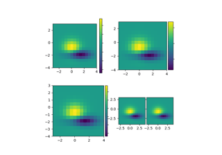

[Axes divider](https://matplotlib.org/stable/gallery/axes_grid1/demo_axes_divider.html#sphx-glr-gallery-axes-grid1-demo-axes-divider-py)

Axes divider

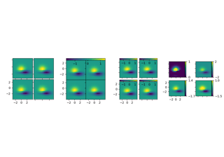

[Demo Axes Grid](https://matplotlib.org/stable/gallery/axes_grid1/demo_axes_grid.html#sphx-glr-gallery-axes-grid1-demo-axes-grid-py)

Demo Axes Grid

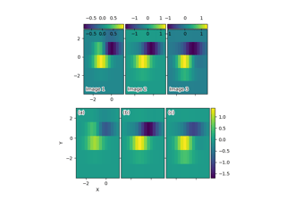

[Axes Grid2](https://matplotlib.org/stable/gallery/axes_grid1/demo_axes_grid2.html#sphx-glr-gallery-axes-grid1-demo-axes-grid2-py)

Axes Grid2

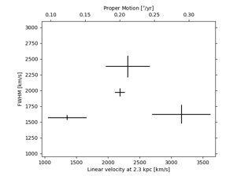

[Parasite Simple2](https://matplotlib.org/stable/gallery/axes_grid1/parasite_simple2.html#sphx-glr-gallery-axes-grid1-parasite-simple2-py)

Parasite Simple2

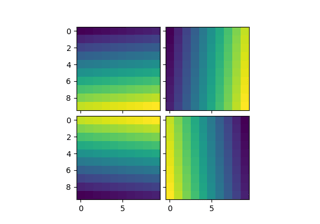

[Simple ImageGrid](https://matplotlib.org/stable/gallery/axes_grid1/simple_axesgrid.html#sphx-glr-gallery-axes-grid1-simple-axesgrid-py)

Simple ImageGrid

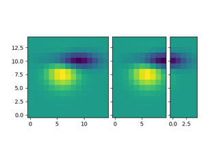

[Simple ImageGrid 2](https://matplotlib.org/stable/gallery/axes_grid1/simple_axesgrid2.html#sphx-glr-gallery-axes-grid1-simple-axesgrid2-py)

Simple ImageGrid 2

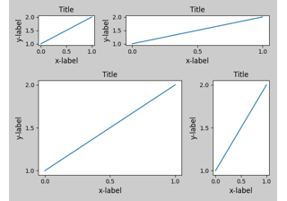

[Tight Layout guide](https://matplotlib.org/stable/tutorials/intermediate/tight_layout_guide.html#sphx-glr-tutorials-intermediate-tight-layout-guide-py)

Tight Layout guide